# Chapter 3 - Full, Semi and Anti Joins

by Edneide Ramalho

14 Junho, 2021

# 1 Full join

It keeps all of both tables.

- Importing the data frames:

```r
library(tidyverse)
library(readr)
inventories <- read_csv("dados/inventories.csv")
inventory_parts <- read_csv("dados/inventory_parts.csv")

inventory_parts_joined <- inventories %>%
  inner_join(inventory_parts, by = c("id" = "inventory_id")) %>%
  select(-id, -version) %>%
  arrange(desc(quantity))

batmobile <- inventory_parts_joined %>%
  filter(set_num == "7784-1") %>%
  select(-set_num)

batwing <- inventory_parts_joined %>%
  filter(set_num == "70916-1") %>%
  select(-set_num)
```

```r
batmobile %>%
  full_join(batwing, by = c("part_num", "color_id"), suffix = c("_batmobile", "_batwing"))
```

```
## # A tibble: 440 x 6
##    part_num color_id quantity_batmobile is_spare_batmobile quantity_batwing
##    <chr>       <dbl>              <dbl> <lgl>                         <dbl>
##  1 3023           72                 62 FALSE                            NA
##  2 2780            0                 28 FALSE                            17
##  3 50950           0                 28 FALSE                             2
##  4 3004           71                 26 FALSE                             2
##  5 43093           1                 25 FALSE                             6
##  6 3004            0                 23 FALSE                             4
##  7 3010            0                 21 FALSE                            NA
##  8 30363           0                 21 FALSE                            NA
##  9 32123b         14                 19 FALSE                            NA
## 10 3622            0                 18 FALSE                             2
## # … with 430 more rows, and 1 more variable: is_spare_batwing <lgl>
```

## 1.1 Replace NA: multiple variables

```r
batmobile %>%
  full_join(batwing, by = c("part_num", "color_id"), suffix = c("_batmobile", "_batwing")) %>%
  replace_na(list(quantity_batmobile = 0,
                  quantity_batwing = 0))
```

```
## # A tibble: 440 x 6
##    part_num color_id quantity_batmobile is_spare_batmobile quantity_batwing
##    <chr>       <dbl>              <dbl> <lgl>                         <dbl>
##  1 3023           72                 62 FALSE                             0
##  2 2780            0                 28 FALSE                            17
##  3 50950           0                 28 FALSE                             2
##  4 3004           71                 26 FALSE                             2
##  5 43093           1                 25 FALSE                             6
##  6 3004            0                 23 FALSE                             4
##  7 3010            0                 21 FALSE                             0
##  8 30363           0                 21 FALSE                             0
##  9 32123b         14                 19 FALSE                             0
## 10 3622            0                 18 FALSE                             2
## # … with 430 more rows, and 1 more variable: is_spare_batwing <lgl>
```

## 1.2 Exercises

### 1.2.1 Differences between Batman and Star Wars

In the video, you compared two sets. Now, you’ll compare two themes, each of which is made up of many sets.

First, you’ll need to join in the `themes`. Recall that doing so requires going through the `sets` first. You’ll use the `inventory_parts_joined` table from the video, which is already available to you in the console.

```
inventory_parts_joined <- inventories %>%
  inner_join(inventory_parts, by = c("id" = "inventory_id")) %>%
  arrange(desc(quantity)) %>%
  select(-id, -version)
```

- In order to join in the themes, you’ll first need to combine the `inventory_parts_joined` and `sets` tables. Keep only the observations that have a match in both tables.
- Then, combine the first join with the `themes` table, using the suffix argument to clarify which table each `name` came from (`"_set"` or `"_theme"`). Keep only the observations that have a match in both tables.

*If your exercise is timing out, you are likely joining the wrong tables, causing the join result to be too big! Check your code carefully!*

```r
library(readr)
sets <- read_csv("dados/sets.csv")
themes <- read_csv("dados/themes.csv")
# Start with inventory_parts_joined table
inventory_parts_joined %>%
  # Combine with the sets table
  inner_join(sets, by = "set_num") %>%
  # Combine with the themes table
  inner_join(themes, by = c("theme_id" = "id"),
            suffix = c("_set", "_theme"))
```

```
## # A tibble: 580,251 x 11
##    set_num part_num color_id quantity is_spare name_set  year theme_id num_parts
##    <chr>   <chr>       <dbl>    <dbl> <lgl>    <chr>    <dbl>    <dbl>     <dbl>
##  1 k34432… 3024           15     1440 FALSE    Lego Mo…  2003      277      2846
##  2 k34433… 3024           15     1170 FALSE    Lego Mo…  2003      277      2126
##  3 40179-1 3024           72      900 FALSE    Persona…  2016      277      4501
##  4 40179-1 3024            0      900 FALSE    Persona…  2016      277      4501
##  5 40179-1 3024           15      900 FALSE    Persona…  2016      277      4501
##  6 40179-1 3024           14      900 FALSE    Persona…  2016      277      4501
##  7 40179-1 3024           71      900 FALSE    Persona…  2016      277      4501
##  8 k34434… 3024           15      810 FALSE    Lego Mo…  2003      277      2216
##  9 21010-1 3023          320      771 FALSE    Robie H…  2011      252      2276
## 10 42055-1 2780            0      724 FALSE    Bucket …  2016        7      3928
## # … with 580,241 more rows, and 2 more variables: name_theme <chr>,
## #   parent_id <dbl>
```

### 1.2.2 **Aggregating each theme**

Previously, you combined tables to compare themes. Before doing this comparison, you’ll want to aggregate the data to learn more about the pieces that are a part of each theme, as well as the colors of those pieces.

The table you created previously has been preloaded for you as `inventory_sets_themes`. It was filtered for each theme, and the objects have been saved as `batman` and `star_wars`.

```r
inventory_sets_themes <- inventory_parts_joined %>%
  inner_join(sets, by = "set_num") %>%
  inner_join(themes, by = c("theme_id" = "id"), suffix = c("_set", "_theme"))

batman <- inventory_sets_themes %>%
  filter(name_theme == "Batman")

star_wars <- inventory_sets_themes %>%
  filter(name_theme == "Star Wars")
```

- Count the part number and color id for the parts in Batman and Star Wars, weighted by quantity.

```r
batman %>%
  count(part_num,color_id, wt = quantity)
```

```
## # A tibble: 3,723 x 3
##    part_num    color_id     n
##    <chr>          <dbl> <dbl>
##  1 10113              0    27
##  2 10113              1     1
##  3 10113              4     1
##  4 10113             15     1
##  5 10113             29     1
##  6 10113            272     2
##  7 10113            297     2
##  8 10113pr0001        0     1
##  9 10113pr0002       70     1
## 10 10124            326     1
## # … with 3,713 more rows
```

```r
star_wars %>%
  count(part_num, color_id, wt = quantity)
```

```
## # A tibble: 3,541 x 3
##    part_num    color_id     n
##    <chr>          <dbl> <dbl>
##  1 10164pr0001       15     1
##  2 10169              4     1
##  3 10169             84     1
##  4 10197              0     4
##  5 10197             72    12
##  6 10201              0    12
##  7 10201              1     1
##  8 10201             15     5
##  9 10201             71    17
## 10 10247              0    21
## # … with 3,531 more rows
```

### 1.2.3 **Full-joining Batman and Star Wars LEGO parts**

Now that you’ve got separate tables for the pieces in the `batman` and `star_wars` themes, you’ll want to be able to combine them to see any similarities or differences between the two themes. The aggregating from the last exercise has been saved as `batman_parts` and `star_wars_parts`, and is preloaded for you.

```r
batman_parts <- batman %>%
  count(part_num, color_id, wt = quantity)

star_wars_parts <- star_wars %>%
  count(part_num, color_id, wt = quantity)
```

- Combine the `star_wars_parts` table with the `batman_parts` table; use the suffix argument to include the `"_batman"` and `"_star_wars"` suffixes.
- Replace all the NA values in the `n_batman` and `n_star_wars` columns with 0s.

```r
batman_parts %>%
  # Combine the star_wars_parts table
  full_join(star_wars_parts, by = c("part_num", "color_id"),
            suffix = c("_batman", "_star_wars")) %>%
  # Replace NAs with 0s in the n_batman and n_star_wars columns
  replace_na(list(n_batman = 0,
                  n_star_wars = 0))
```

```
## # A tibble: 5,727 x 4
##    part_num    color_id n_batman n_star_wars
##    <chr>          <dbl>    <dbl>       <dbl>
##  1 10113              0       27           0
##  2 10113              1        1           0
##  3 10113              4        1           0
##  4 10113             15        1           0
##  5 10113             29        1           0
##  6 10113            272        2           0
##  7 10113            297        2           0
##  8 10113pr0001        0        1           0
##  9 10113pr0002       70        1           0
## 10 10124            326        1           0
## # … with 5,717 more rows
```

### 1.2.4 **Comparing Batman and Star Wars LEGO parts**

The table you created in the last exercise includes the part number of each piece, the color id, and the number of each piece in the Star Wars and Batman themes. However, we have more information about each of these parts that we can gain by combining this table with some of the information we have in other tables. Before we compare the themes, let’s ensure that we have enough information to make our findings more interpretable. The table from the last exercise has been saved as `parts_joined` and is preloaded for you.

```r
parts_joined <- batman_parts %>%
  full_join(star_wars_parts, by = c("part_num", "color_id"), suffix = c("_batman", "_star_wars")) %>%
  replace_na(list(n_batman = 0, n_star_wars = 0))
```

- Sort the number of star wars pieces in the `parts_joined` table in descending order.
- Join the `colors` table to the `parts_joined` table.
- Combine the `parts` table to the previous join; add `"_color"` and `"_part"` suffixes to specify whether or not the information came from the `colors` table or the `parts` table.

```r
# Importing colors table
library(readr)
colors <- read_csv("dados/colors.csv")
glimpse(colors)
```

```
## Rows: 135
## Columns: 4
## $ id       <dbl> -1, 0, 1, 2, 3, 4, 5, 6, 7, 8, 9, 10, 11, 12, 13, 14, 15, 17,…
## $ name     <chr> "Unknown", "Black", "Blue", "Green", "Dark Turquoise", "Red",…
## $ rgb      <chr> "0033B2", "05131D", "0055BF", "237841", "008F9B", "C91A09", "…
## $ is_trans <lgl> FALSE, FALSE, FALSE, FALSE, FALSE, FALSE, FALSE, FALSE, FALSE…
```

```r
# Importing parts table
library(readr)
parts <- read_csv("dados/parts.csv")
glimpse(parts)
```

```
## Rows: 25,993
## Columns: 3
## $ part_num    <chr> "0687b1", "0901", "0902", "0903", "0904", "1", "10", "1001…
## $ name        <chr> "Set 0687 Activity Booklet 1", "Baseplate 16 x 30 with Set…
## $ part_cat_id <dbl> 17, 1, 1, 1, 1, 7, 1, 17, 17, 17, 17, 17, 44, 13, 27, 27, …
```

```r
parts_joined %>%
  # Join the number of star wars pieces in descending order
  dplyr::arrange(desc(n_star_wars)) %>%
  # Join the colors table to the parts_joined table
  inner_join(colors, by = c("color_id" = "id")) %>%
  # Join the parts table to the previous join
  inner_join(parts, by = "part_num", suffix = c("_color", "_part"))
```

```
## # A tibble: 5,726 x 9
##    part_num color_id n_batman n_star_wars name_color  rgb   is_trans name_part
##    <chr>       <dbl>    <dbl>       <dbl> <chr>       <chr> <lgl>    <chr>
##  1 2780            0      345         784 Black       0513… FALSE    Technic Pi…
##  2 32062           0       21         446 Black       0513… FALSE    Technic Ax…
##  3 3023            0      158         309 Black       0513… FALSE    Plate 1 x 2
##  4 32123b          7        0         284 Light Gray  9BA1… FALSE    Technic Bu…
##  5 3021           72       49         226 Dark Bluis… 6C6E… FALSE    Plate 2 x 3
##  6 3023           71      104         219 Light Blui… A0A5… FALSE    Plate 1 x 2
##  7 4519            0        0         208 Black       0513… FALSE    Technic Ax…
##  8 6558            1       79         199 Blue        0055… FALSE    Technic Pi…
##  9 6141           36       68         192 Trans-Red   C91A… TRUE     Plate Roun…
## 10 3713            7        0         190 Light Gray  9BA1… FALSE    Technic Bu…
## # … with 5,716 more rows, and 1 more variable: part_cat_id <dbl>
```

# 2 The semi- and anti-join verbs

## 2.1 Filtering joins

- Keeps or removes observations from the first table
- Doesn’t add new variables
- `semi_join()` What observations in X are **also** in Y?
- `anti_join()` What observations in X are not in Y?

## 2.2 The semi join

```r
glimpse(batmobile)
```

```
## Rows: 173
## Columns: 4
## $ part_num <chr> "3023", "2780", "50950", "3004", "43093", "3004", "3010", "30…
## $ color_id <dbl> 72, 0, 0, 71, 1, 0, 0, 0, 14, 0, 320, 0, 0, 0, 0, 0, 0, 72, 0…
## $ quantity <dbl> 62, 28, 28, 26, 25, 23, 21, 21, 19, 18, 18, 18, 16, 14, 14, 1…
## $ is_spare <lgl> FALSE, FALSE, FALSE, FALSE, FALSE, FALSE, FALSE, FALSE, FALSE…
```

```r
glimpse(batwing)
```

```
## Rows: 309
## Columns: 4
## $ part_num <chr> "3023", "3024", "3623", "11477", "99207", "2780", "3666", "22…
## $ color_id <dbl> 0, 0, 0, 0, 71, 0, 0, 0, 0, 0, 72, 72, 72, 4, 0, 71, 72, 46, …
## $ quantity <dbl> 22, 22, 20, 18, 18, 17, 16, 14, 14, 13, 12, 12, 12, 12, 10, 1…
## $ is_spare <lgl> FALSE, FALSE, FALSE, FALSE, FALSE, FALSE, FALSE, FALSE, FALSE…
```

```r
batmobile %>%
  semi_join(batwing, by = c("color_id", "part_num"))
```

```
## # A tibble: 45 x 4
##    part_num color_id quantity is_spare
##    <chr>       <dbl>    <dbl> <lgl>
##  1 2780            0       28 FALSE
##  2 50950           0       28 FALSE
##  3 3004           71       26 FALSE
##  4 43093           1       25 FALSE
##  5 3004            0       23 FALSE
##  6 3622            0       18 FALSE
##  7 4286            0       16 FALSE
##  8 3039            0       12 FALSE
##  9 4274           71       12 FALSE
## 10 3001            0       11 FALSE
## # … with 35 more rows
```

When we do a semi_join we reduce the data frame. Only color_ids and part_num in batmobile that are also in Batwing will be returned.

## 2.3 The anti join

It is the opposite of semi join. We are asking what observations in batmobile are not in batwing?

```r
batmobile %>%
  anti_join(batwing, by = c("color_id", "part_num"))
```

```
## # A tibble: 128 x 4
##    part_num color_id quantity is_spare
##    <chr>       <dbl>    <dbl> <lgl>
##  1 3023           72       62 FALSE
##  2 3010            0       21 FALSE
##  3 30363           0       21 FALSE
##  4 32123b         14       19 FALSE
##  5 50950         320       18 FALSE
##  6 6541            0       18 FALSE
##  7 3040b           0       14 FALSE
##  8 3298            0       14 FALSE
##  9 3660            0       14 FALSE
## 10 42022           0       14 FALSE
## # … with 118 more rows
```

## 2.4 The joining verbs

- `inner_join`
- `left_join`
- `right_join`
- `full_join` -> Keep all observations from both tables.
- `semi_join` -> Filter the first table for observations that match the second.
- `anti_join` -> Filter the first table for observations that don’t match the second.

## 2.5 Exercises

### 2.5.1 **Something within one set but not another**

In the videos, you learned how to filter using the semi- and anti-join verbs to answer questions you have about your data. Let’s focus on the `batwing` dataset, and use our skills to determine which parts are in both the `batwing` and `batmobile` sets, and which sets are in one, but not the other. While answering these questions, we’ll also be determining whether or not the parts we’re looking at in both sets also have the same color in common.

- Filter the batwing set for parts that are **also** in the batmobile, whether or not they have the same color.

```r
batwing %>%
  semi_join(batmobile, by = "part_num")
```

```
## # A tibble: 126 x 4
##    part_num color_id quantity is_spare
##    <chr>       <dbl>    <dbl> <lgl>
##  1 3023            0       22 FALSE
##  2 3024            0       22 FALSE
##  3 3623            0       20 FALSE
##  4 2780            0       17 FALSE
##  5 3666            0       16 FALSE
##  6 3710            0       14 FALSE
##  7 6141            4       12 FALSE
##  8 2412b          71       10 FALSE
##  9 6141           72       10 FALSE
## 10 6558            1        9 FALSE
## # … with 116 more rows
```

- Filter the batwing set for parts that **aren’t** also in the batmobile, whether or not they have the same color.

  ```r
  batwing %>%
    anti_join(batmobile, by = "part_num")
  ```

  ```
  ## # A tibble: 183 x 4
  ##    part_num color_id quantity is_spare
  ##    <chr>       <dbl>    <dbl> <lgl>
  ##  1 11477           0       18 FALSE
  ##  2 99207          71       18 FALSE
  ##  3 22385           0       14 FALSE
  ##  4 99563           0       13 FALSE
  ##  5 10247          72       12 FALSE
  ##  6 2877           72       12 FALSE
  ##  7 61409          72       12 FALSE
  ##  8 11153           0       10 FALSE
  ##  9 98138          46       10 FALSE
  ## 10 2419           72        9 FALSE
  ## # … with 173 more rows
  ```

### 2.5.2 What colors are included in at least one set?

Besides comparing two sets directly, you could also use a filtering join like `semi_join` to find out which colors ever appear in any inventory part. Some of the colors could be optional, meaning they aren’t included in any sets.

The `inventory_parts` and `colors` tables have been preloaded for you.

- Use the `inventory_parts` table to find the colors that are included in at least one set.

```r
# Use inventory_parts to find colors included in at least one set
colors %>%
    semi_join(inventory_parts, by = c("id" = "color_id"))
```

```
## # A tibble: 131 x 4
##       id name           rgb    is_trans
##    <dbl> <chr>          <chr>  <lgl>
##  1    -1 Unknown        0033B2 FALSE
##  2     0 Black          05131D FALSE
##  3     1 Blue           0055BF FALSE
##  4     2 Green          237841 FALSE
##  5     3 Dark Turquoise 008F9B FALSE
##  6     4 Red            C91A09 FALSE
##  7     5 Dark Pink      C870A0 FALSE
##  8     6 Brown          583927 FALSE
##  9     7 Light Gray     9BA19D FALSE
## 10     8 Dark Gray      6D6E5C FALSE
## # … with 121 more rows
```

### 2.5.3 Which set is missing version 1?

Each set included in the LEGO data has an associated version number. We want to understand the version we are looking at to learn more about the parts that are included. Before doing that, we should confirm that there aren’t any sets that are missing a particular version.

Let’s start by looking at the first version of each set to see if there are any sets that don’t include a first version.

- Use `filter()` to extract `version` `1` from the `inventories` table; save the filter to `version_1_inventories`.
- Use `anti_join` to combine `version_1_inventories` with `sets` to determine which set is missing a version 1.

```r
# Use filter() to extract version 1
version_1_inventories <- inventories %>%
    filter(version == 1)


# Use anti_join() to find which set is missing a version 1
sets %>%
    anti_join(version_1_inventories, by = "set_num")
```

```
## # A tibble: 4 x 5
##   set_num name                                           year theme_id num_parts
##   <chr>   <chr>                                         <dbl>    <dbl>     <dbl>
## 1 70904   Clayface Splat Attack                          2017      484         0
## 2 70906   LEGO® Batman Movie - The Joker™ Notorious Lo…  2017      484         0
## 3 75160   U-wing                                         2017      158       107
## 4 76081-1 The Milano vs. The Abilisk                     2017      483       456
```

# 3 Visualizing set differences

## 3.1 Aggregating sets into colors

```r
batmobile_colors <- batmobile %>%
  group_by(color_id) %>%
  summarize(total = sum(quantity))

batmobile_colors
```

```
## # A tibble: 12 x 2
##    color_id total
##       <dbl> <dbl>
##  1        0   543
##  2        1    33
##  3        4    16
##  4       14    20
##  5       15    16
##  6       36    15
##  7       57     8
##  8       71   202
##  9       72   160
## 10      182     8
## 11      297     4
## 12      320    27
```

```r
batwing_colors <- batwing %>%
  group_by(color_id) %>%
  summarize(total = sum(quantity))

batwing_colors
```

```
## # A tibble: 20 x 2
##    color_id total
##       <dbl> <dbl>
##  1        0   418
##  2        1    45
##  3        4    81
##  4       14    22
##  5       15    22
##  6       19    10
##  7       25     1
##  8       34     3
##  9       36     9
## 10       46    21
## 11       47     4
## 12       52     4
## 13       57     3
## 14       70    16
## 15       71   158
## 16       72   213
## 17       78     3
## 18       80     4
## 19      179     1
## 20      182    14
```

## 3.2 Comparing color schemes of sets

```r
colors_df <- batmobile_colors %>%
  full_join(batwing_colors, by = "color_id",
            suffix = c("_batmobile", "_batwing")) %>%
  replace_na(list(total_batmobile = 0,
                  total_batwing = 0))
colors_df
```

```
## # A tibble: 22 x 3
##    color_id total_batmobile total_batwing
##       <dbl>           <dbl>         <dbl>
##  1        0             543           418
##  2        1              33            45
##  3        4              16            81
##  4       14              20            22
##  5       15              16            22
##  6       36              15             9
##  7       57               8             3
##  8       71             202           158
##  9       72             160           213
## 10      182               8            14
## # … with 12 more rows
```

## 3.3 Adding the colors names

```r
colors_df <- colors_df %>%
  inner_join(colors, by = c("color_id" = "id"))
colors_df
```

```
## # A tibble: 22 x 6
##    color_id total_batmobile total_batwing name              rgb    is_trans
##       <dbl>           <dbl>         <dbl> <chr>             <chr>  <lgl>
##  1        0             543           418 Black             05131D FALSE
##  2        1              33            45 Blue              0055BF FALSE
##  3        4              16            81 Red               C91A09 FALSE
##  4       14              20            22 Yellow            F2CD37 FALSE
##  5       15              16            22 White             FFFFFF FALSE
##  6       36              15             9 Trans-Red         C91A09 TRUE
##  7       57               8             3 Trans-Neon Orange FF800D TRUE
##  8       71             202           158 Light Bluish Gray A0A5A9 FALSE
##  9       72             160           213 Dark Bluish Gray  6C6E68 FALSE
## 10      182               8            14 Trans-Orange      F08F1C TRUE
## # … with 12 more rows
```

## 3.4 Adding percentages

```r
colors_df <- colors_df %>%
  mutate(total_batmobile = total_batmobile/sum(total_batmobile),
         total_batwing = total_batwing/sum(total_batwing))
colors_df
```

```
## # A tibble: 22 x 6
##    color_id total_batmobile total_batwing name              rgb    is_trans
##       <dbl>           <dbl>         <dbl> <chr>             <chr>  <lgl>
##  1        0         0.516         0.397   Black             05131D FALSE
##  2        1         0.0314        0.0428  Blue              0055BF FALSE
##  3        4         0.0152        0.0770  Red               C91A09 FALSE
##  4       14         0.0190        0.0209  Yellow            F2CD37 FALSE
##  5       15         0.0152        0.0209  White             FFFFFF FALSE
##  6       36         0.0143        0.00856 Trans-Red         C91A09 TRUE
##  7       57         0.00760       0.00285 Trans-Neon Orange FF800D TRUE
##  8       71         0.192         0.150   Light Bluish Gray A0A5A9 FALSE
##  9       72         0.152         0.202   Dark Bluish Gray  6C6E68 FALSE
## 10      182         0.00760       0.0133  Trans-Orange      F08F1C TRUE
## # … with 12 more rows
```

## 3.5 The difference between fractions

```r
colors_joined <- colors_df %>%
  mutate(difference = total_batmobile - total_batwing)
colors_joined
```

```
## # A tibble: 22 x 7
##    color_id total_batmobile total_batwing name         rgb   is_trans difference
##       <dbl>           <dbl>         <dbl> <chr>        <chr> <lgl>         <dbl>
##  1        0         0.516         0.397   Black        0513… FALSE       0.119
##  2        1         0.0314        0.0428  Blue         0055… FALSE      -0.0114
##  3        4         0.0152        0.0770  Red          C91A… FALSE      -0.0618
##  4       14         0.0190        0.0209  Yellow       F2CD… FALSE      -0.00190
##  5       15         0.0152        0.0209  White        FFFF… FALSE      -0.00570
##  6       36         0.0143        0.00856 Trans-Red    C91A… TRUE        0.00570
##  7       57         0.00760       0.00285 Trans-Neon … FF80… TRUE        0.00475
##  8       71         0.192         0.150   Light Bluis… A0A5… FALSE       0.0418
##  9       72         0.152         0.202   Dark Bluish… 6C6E… FALSE      -0.0504
## 10      182         0.00760       0.0133  Trans-Orange F08F… TRUE       -0.00570
## # … with 12 more rows
```

## 3.6 Visualizing the data

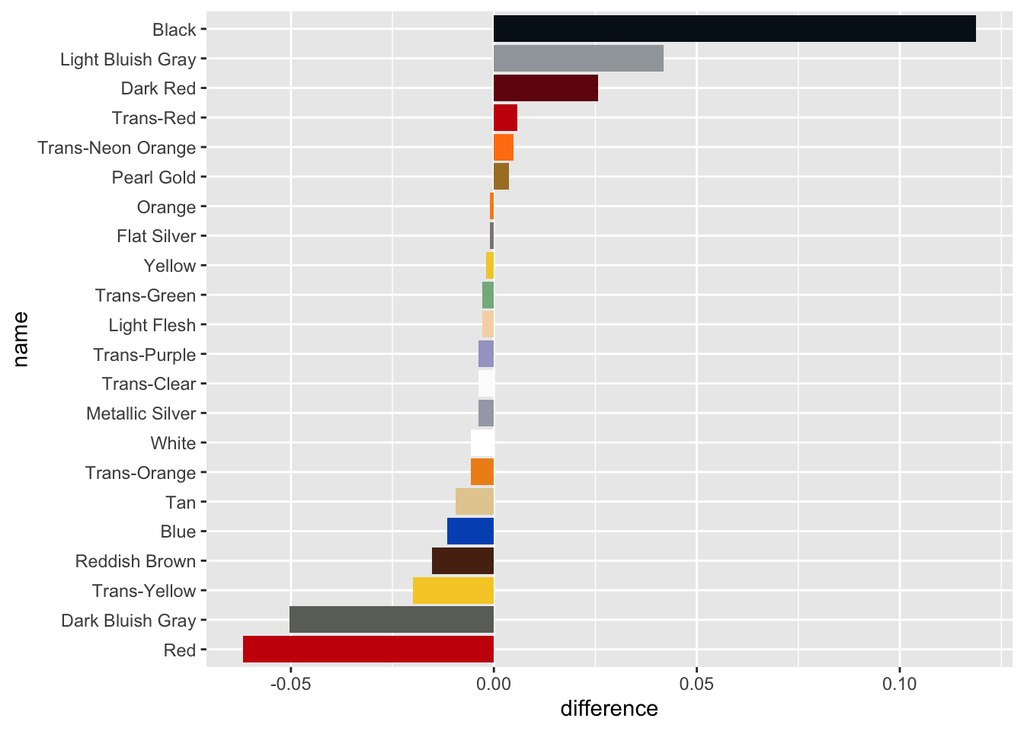

```r
library(ggplot2)
library(forcats)

color_palette <- setNames(paste0("#", colors_joined$rgb), colors_joined$name)

colors_joined %>%
  mutate(name = fct_reorder(name, difference)) %>%
  ggplot(aes(name, difference, fill = name)) +
  geom_col() +
  coord_flip() +
  scale_fill_manual(values = color_palette, guide = FALSE)
```

Colors with positive difference are more common in the batmobile set, while colors with negative difference are more common in the batwing set.

## 3.7 Exercises

### 3.7.1 **Aggregating sets to look at their differences**

To compare two individual sets, and the kinds of LEGO pieces that comprise them, we’ll need to aggregate the data into separate themes. Additionally, as we saw in the video, we’ll want to add a column so that we can understand the percentages of specific pieces that are part of each set, rather than looking at the numbers of pieces alone.

The `inventory_parts_themes` table has been preloaded for you.

```r
inventory_parts_themes <- inventories %>%
  inner_join(inventory_parts, by = c("id" = "inventory_id")) %>%
  arrange(desc(quantity)) %>%
  select(-id, -version) %>%
  inner_join(sets, by = "set_num") %>%
  inner_join(themes, by = c("theme_id" = "id"), suffix = c("_set", "_theme"))
```

- Add a filter for the `"Batman"` set to create the `batman_colors` object.
- Add a percent column to `batman_colors` that displays the total divided by the sum of the total.
- Repeat the steps to filter and aggregate the `"Star Wars"` set data to create the `star_wars_colors` object.
  - Again, add a percent column to display the percent of the total.

```r
batman_colors <- inventory_parts_themes %>%
  # Filter the inventory_parts_themes table for the Batman theme
  filter(name_theme == "Batman") %>%
  group_by(color_id) %>%
  summarize(total = sum(quantity)) %>%
  # Add a percent column of the total divided by the sum of the total
  mutate(percent = total/sum(total))

# Filter and aggregate the Star Wars set data; add a percent column
star_wars_colors <- inventory_parts_themes %>%
  filter(name_theme == "Star Wars") %>%
  group_by(color_id) %>%
  summarize(total = sum(quantity)) %>%
  mutate(percent = total/sum(total))
```

### 3.7.2 **Combining sets**

The data you aggregated in the last exercise has been preloaded for you as `batman_colors` and `star_wars_colors`. Prior to visualizing the data, you’ll want to combine these tables to be able to directly compare the themes’ colors.

```
batman_colors <- inventory_parts_themes %>%
  filter(name_theme == "Batman") %>%
  group_by(color_id) %>%
  summarize(total = sum(quantity)) %>%
  mutate(percent = total / sum(total))

star_wars_colors <- inventory_parts_themes %>%
  filter(name_theme == "Star Wars") %>%
  group_by(color_id) %>%
  summarize(total = sum(quantity)) %>%
  mutate(percent = total / sum(total))
```

- Join the `batman_colors` and `star_wars_colors` tables; be sure to include all observations from both tables.
- Replace the NAs in the `total_batman` and `total_star_wars` columns.

```r
batman_colors %>%
  # Join the Batman and Star Wars colors
  full_join(star_wars_colors, by = "color_id", suffix = c("_batman", "_star_wars")) %>%
  # Replace NAs in the total_batman and total_star_wars columns
  replace_na(list(total_batman = 0,
                  total_star_wars = 0)) %>%
  inner_join(colors, by = c("color_id" = "id"))
```

```
## # A tibble: 73 x 8
##    color_id total_batman percent_batman total_star_wars percent_star_wars name
##       <dbl>        <dbl>          <dbl>           <dbl>             <dbl> <chr>
##  1       -1            3       0.000112               1         0.0000277 Unkno…
##  2        0         7638       0.286               8935         0.247     Black
##  3        1          599       0.0224               834         0.0231    Blue
##  4        2          312       0.0117               137         0.00379   Green
##  5        4         1019       0.0381              1282         0.0355    Red
##  6        5            7       0.000262               0        NA         Dark …
##  7       10            8       0.000299               9         0.000249  Brigh…
##  8       14          837       0.0313               338         0.00936   Yellow
##  9       15         1105       0.0414              2288         0.0634    White
## 10       19          734       0.0275              1571         0.0435    Tan
## # … with 63 more rows, and 2 more variables: rgb <chr>, is_trans <lgl>
```

- Add a `difference` column that calculates the difference between `percent_batman` and `percent_star_wars`, and a `total` column, which is the sum of `total_batman` and `total_star_wars`.
- Add a `filter` to select observations where `total` is at least 200.

```r
batman_colors %>%
  full_join(star_wars_colors, by = "color_id", suffix = c("_batman", "_star_wars")) %>%
  replace_na(list(total_batman = 0, total_star_wars = 0)) %>%
  inner_join(colors, by = c("color_id" = "id")) %>%
  # Create the difference and total columns
  mutate(difference = percent_batman - percent_star_wars,
         total = total_batman + total_star_wars) %>%
  # Filter for totals greater than 200
  filter(total >= 200)
```

```
## # A tibble: 30 x 10
##    color_id total_batman percent_batman total_star_wars percent_star_wars name
##       <dbl>        <dbl>          <dbl>           <dbl>             <dbl> <chr>
##  1        0         7638        0.286              8935           0.247   Black
##  2        1          599        0.0224              834           0.0231  Blue
##  3        2          312        0.0117              137           0.00379 Green
##  4        4         1019        0.0381             1282           0.0355  Red
##  5       14          837        0.0313              338           0.00936 Yellow
##  6       15         1105        0.0414             2288           0.0634  White
##  7       19          734        0.0275             1571           0.0435  Tan
##  8       25          208        0.00778             214           0.00593 Orange
##  9       28          760        0.0284              446           0.0124  Dark …
## 10       36          242        0.00906             467           0.0129  Trans…
## # … with 20 more rows, and 4 more variables: rgb <chr>, is_trans <lgl>,
## #   difference <dbl>, total <dbl>
```

### 3.7.3 **Visualizing the difference: Batman and Star Wars**

In the last exercise, you created `colors_joined`. Now you’ll create a bar plot with one bar for each color (`name`), showing the difference in percentages.

Because factors and visualization are beyond the scope of this course, we’ve done some processing for you: here is the code that created the `colors_joined` table that will be used in the video.

```r
colors_joined <- batman_colors %>%
  full_join(star_wars_colors, by = "color_id", suffix = c("_batman", "_star_wars")) %>%
  replace_na(list(total_batman = 0, total_star_wars = 0)) %>%
  inner_join(colors, by = c("color_id" = "id")) %>%
  mutate(difference = percent_batman - percent_star_wars,
         total = total_batman + total_star_wars) %>%
  filter(total >= 200) %>%
  mutate(name = fct_reorder(name, difference))
```

```r
colors_joined <- colors_joined %>%
  mutate(rgb = paste0("#", rgb))
```

- Create a bar plot using the `colors_joined` table to display the most prominent colors in the Batman and Star Wars themes, with the bars colored by their `name`.

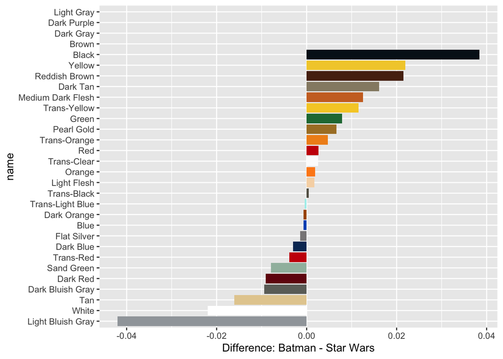

```r
color_palette <- setNames(colors_joined$rgb, colors_joined$name)
# Create a bar plot using colors_joined and the name and difference columns
ggplot(colors_joined, aes(name, difference, fill = name)) +
  geom_col() +
  coord_flip() +
  scale_fill_manual(values = color_palette, guide = FALSE) +
  labs(y = "Difference: Batman - Star Wars")
```